# Assignment 2

Ranieri Martin 967158

December 2021

## Part A

Consider the Disability.csv data set on the distribution of the type of disability (limiting, non-limiting, none) according to age.

```r
ds = read.csv(file = 'Disability.csv', sep=';')
```

### Create a two-way contingency table using standard R tools

```r
t = table(ds)
t
```

```
##        Disability
## ï..Age  Limiting Non-limiting None
##   16-17       58           74  801
##   18-19       66           70  768
##   20-24      175          173 1684
##   25-34      431          422 3157
##   35-44      314          242 1465
##   45-54      479          271 1167
##   55-64      557          393  851
##   65-74      506          392  643
```

### Use the output above as input for the CTAShiny() app

```r
library(CTAShiny)
```

```r
#CTAShiny()
```

### Write a few lines of comments on the analysis using the outputs (also visual) from the CTAShiny() app

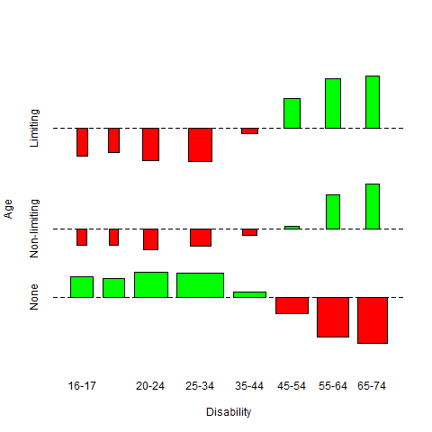

### What happens if we drop the ’None’ category from the variable Disability?

```r
dsp = ds[ds$Disability != 'None', ]
chisq.test(dsp$ï..Age, dsp$Disability)
```

```
##
##  Pearson's Chi-squared test
##
## data:  dsp$ï..Age and dsp$Disability
## X-squared = 47.429, df = 7, p-value = 4.603e-08
```

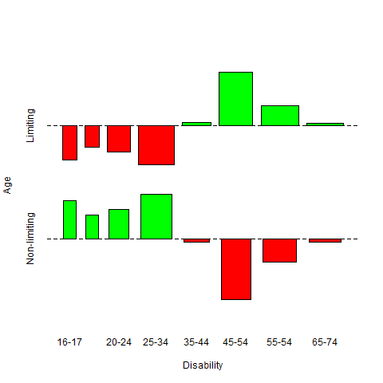

…

# Part B

Consider the `Yogurt.csv` data set on nutritional facts about fat-free and natural yogurts

```r
yg = read.csv(file = 'Yogurt.csv', sep=';')
yg = yg[yg$ï..Brand != 'Vitasnella', ]
N = length(yg[,1])
```

### After scaling the variables, compute the Euclidean distance matrix

```r
dists = matrix(1:(N*N), nrow = N, ncol = N)
euc_dist = function(a, b) sqrt(sum((a - b)^2))

# scaling
for(i in 2:length(yg)){
  yg[i] = scale(yg[i])
}

# distance matrix
for(i in 1:N){
  for(j in 1:N){
    dists[i,j] = euc_dist(yg[i,2:6], yg[j,2:6])
  }
}
dists
```

```
##            [,1]      [,2]      [,3]     [,4]     [,5]      [,6]     [,7]
##  [1,] 0.0000000 0.1848012 0.1068111 2.987145 2.863391 0.2421110 4.537209
##  [2,] 0.1848012 0.0000000 0.2614905 2.965872 2.753870 0.2035483 4.436135
##  [3,] 0.1068111 0.2614905 0.0000000 2.990588 2.838345 0.2464062 4.575185
##  [4,] 2.9871451 2.9658719 2.9905880 0.000000 3.872635 3.0550803 2.317768
##  [5,] 2.8633914 2.7538696 2.8383448 3.872635 0.000000 2.6529109 4.571276
##  [6,] 0.2421110 0.2035483 0.2464062 3.055080 2.652911 0.0000000 4.539737
##  [7,] 4.5372089 4.4361352 4.5751849 2.317768 4.571276 4.5397373 0.000000
##  [8,] 3.3990707 3.3511724 3.4419119 4.490588 5.004076 3.4525736 5.230416
##  [9,] 2.5727948 2.5126909 2.6199918 3.429399 3.912312 2.6648544 4.458735
## [10,] 2.5249754 2.4784174 2.5707047 3.068434 3.774006 2.5071066 3.791577
## [11,] 3.8347890 3.9470598 3.7414955 4.088780 4.424722 3.8716725 6.216176
## [12,] 2.8503987 2.8733422 2.8566248 1.064741 4.393905 2.9682546 2.984932
## [13,] 0.8099755 0.7546763 0.8705289 2.446316 3.069076 0.8999512 3.868542
## [14,] 0.3417872 0.4218812 0.3181404 2.774243 2.891262 0.4953968 4.419622
```

[output cut: 51 more lines]

### Use the cmdscale() function to perform a multidimensional scaling on the data and save the coordinates of the first two principal coordinates

```r
coord = cmdscale(dists, k = 2)
df = as.data.frame(coord)
df['brand'] = yg$ï..Brand
df
```

```
##             V1          V2                brand
## 1  -0.88430981 -0.38178105   Sterzing -Vipiteno
## 2  -0.72999055 -0.43702223            Esselunga
## 3  -0.95768413 -0.32904867                 Coop
## 4   0.79615802  1.97822131               Muller
## 5  -0.03353419  0.07902116                 Fage
## 6  -0.84337092 -0.43542186              Galbani
## 7   3.07019406  1.80381024                 Yomo
## 8   0.32701823 -1.93092987                  Ayo
## 9   0.06726737 -0.32731853                Zymil
## 10  0.56192854 -0.13474238                 Land
## 11 -2.98106907  2.62979539           Milk Kefir
## 12  0.35041665  1.71330350            Granarolo
## 13 -0.21898870 -0.21895791              Activia
## 14 -0.87925072 -0.14578958                 Mila
## 15 -0.76454449 -0.72096099            Amalattea
## 16  0.92924340 -1.05715771           Scaldasole
## 17  2.01111427  0.61162634                Delta
## 18 -0.84337092 -0.43542186             Parmalat
## 19 -0.84337092 -0.43542186   Cenrale latte Roma
## 20 -0.83461390 -0.77520326 Cenrale latte Milano
## 21  2.70075779 -1.05060018          Danio snack
```

### Plot the yogurts labels using the coordinates found above.

```r
library(ggrepel)
```

```r
sp = ggplot(df, aes(x = V1, y = V2)) +
    geom_point()

sp +
  geom_text_repel(aes(label = brand), size = 3)
```

[figure not shown]

```r
sp +
  geom_label_repel(aes(label = brand), size = 3)
```

[output not shown]

### Comment on the results

A previous computation was made including `Vitasnella` brand. It provided inconclusive results due to the fact that its record report wrong scaled values. That record was removed and the multidimensional scaling was performed again. `V1` X-axis seems to be related to how much raw milk has been refined (positive values) or preserved keeping original nutrients like fat (negative ones). `V2` Y-axis seems to be related to the density of nutrients (positive) or their lacks (negative)

No clustering techniques was applied, data seems generated from a single process with a (skew) bivariate normal distribution.

## Part C

Consider the dataset from the Health Survey for England (HSE) 2019 and related documentation in the zip file `HSE2019.zip`

### Try to work out two suitable subsets of variables to perform the CCA after pre-processing the file

See *`cleaner.py`* script

```python
import pandas as pd
import io

# remove bad chraraters
str = open('hse_2019_eul_20211006.csv', 'rt').read()
str = bytes(str, 'utf-8').decode('utf-8', 'ignore')
data = io.StringIO(str)
df = pd.read_csv(data, sep=",")

# convert to float as much as possible
for c in df.columns:
    df[c] = pd.to_numeric(df[c], errors='coerce')

# drop categorical columns and save all
df = df.dropna(axis=1, how='all', )

# a fast look to levels
numeric_levels = {c:len(set(df[c].dropna())) for c in df.columns}
numeric_levels = dict(sorted(numeric_levels.items(), key=lambda item: item[1]))

# columns choosen
group_a = ['SYS1OM', 'DIAS1OM', 'PULS1OM', 'MAP1OM', 'SYS2OM', 'DIAS2OM', 'PULS2OM', 'MAP2OM', 'SYS3OM', 'DIAS3OM', 'PULS3OM', 'MAP3OM', ]
group_b = ['Height', 'HtM17', 'Weight', 'WtM17', 'HtSR', 'WtSR', 'EstHt2', 'EstWt2', 'HtVal', 'WtVal', 'WtVal2', 'BMI', 'BMIVal', 'BMIVal2', 'BMIsr', 'waist1', 'hip1', 'waist2', 'hip2', 'waist3', 'hip3', 'wstval', 'hipval', 'whval', ]

small_a = ['SYS3OM', 'DIAS3OM', 'PULS3OM', 'MAP3OM', ]
small_b = ['HtVal', 'WtVal', 'wstval', 'hipval', 'whval', ]

# drop columns with too mani NaNs
how_many_not_nans = {c:len(df[c].dropna()) for c in df.columns}

for k, v in how_many_not_nans.items():
    if v < 5000:
        try:
            group_a.remove(k)
        except:
            pass
        try:
            group_b.remove(k)
        except:
            pass
# save
dt = df[group_a + group_b].dropna()
dt.to_csv('hse-clean.csv', index=False)
```

```r
hse = read.csv(file = 'hse-clean.csv')
for(i in 1:length(hse)){
  hse[i] = scale(hse[i])
}
```

### Perform a similar analysis as in the above example on the HSE dataset choosing the right variables for canonical correlation analysis

```r
X = hse[,c('SYS1OM', 'DIAS1OM', 'PULS1OM', 'MAP1OM')]
Y = hse[,c('HtVal', 'WtVal', 'wstval', 'hipval', 'whval', 'BMIVal')]

res = cc(X,Y)

#cc_results$xcoef
#cc_results$ycoef
```

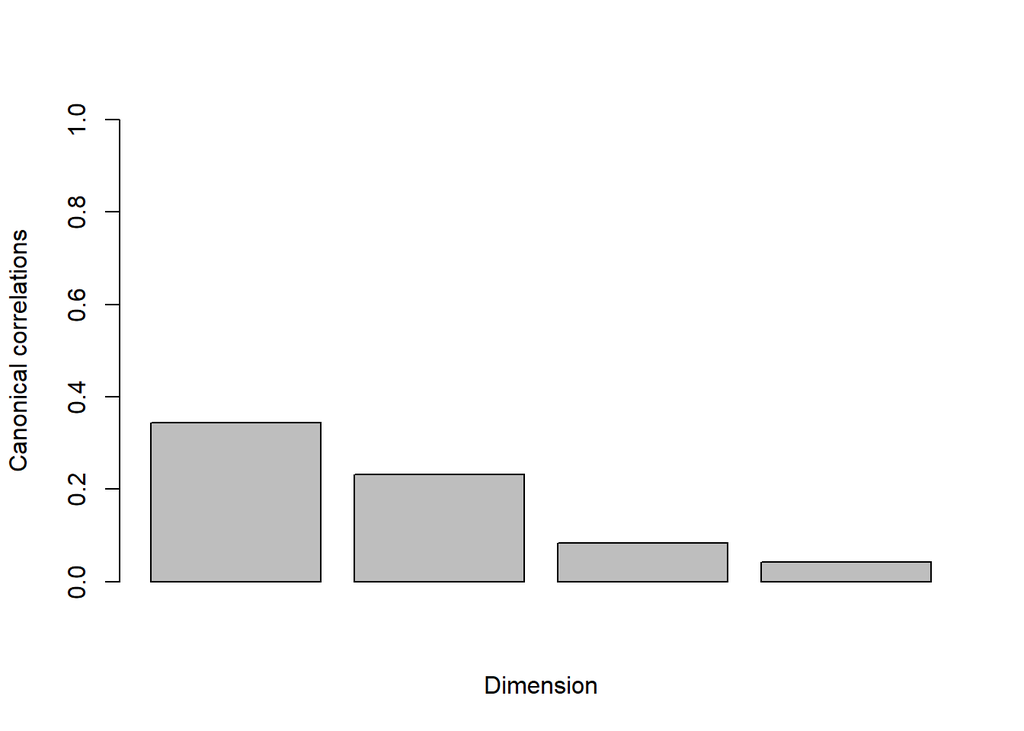

```r
barplot(res$cor, xlab = "Dimension", ylab = "Canonical correlations", ylim = c(0,1))
```

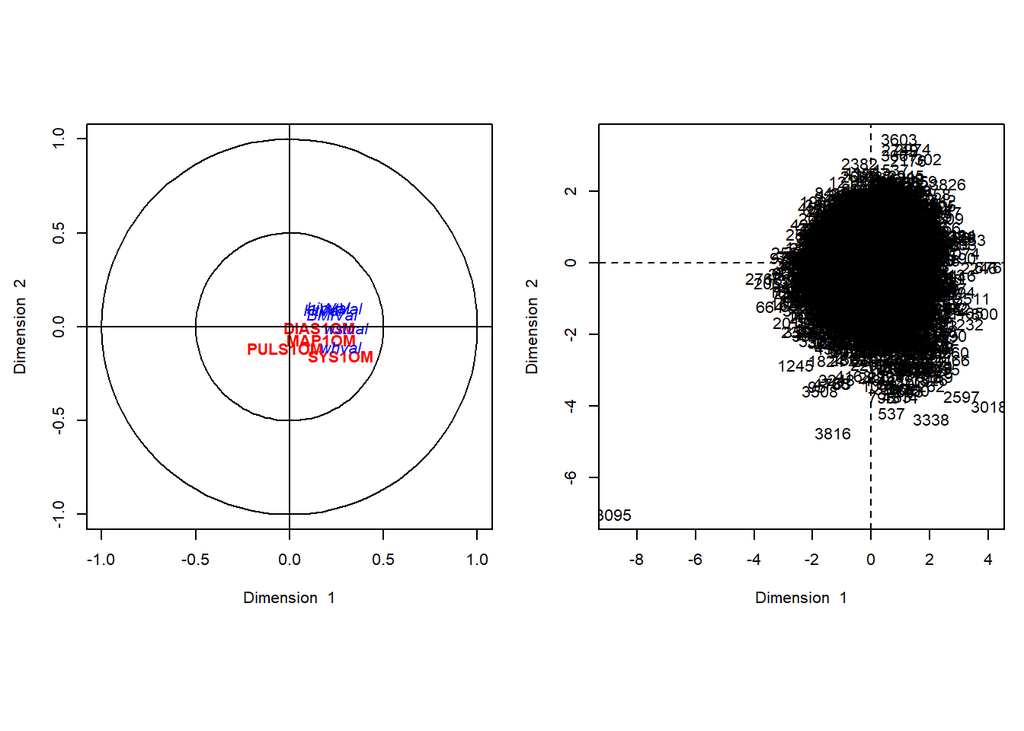

```r
plt.cc(res, 1, 2, var.label = TRUE)
```

### Motivate this choice

The first subset includes cardio measurements like pressures and heartbeat rate. The second subset includes external morphological measurements like height and weight. This canonical correlation analysis has been design to prove that there are common hidden variables behind external body form and internal body performance. At the first time this analysis has been computed with a full set of the interested variables. Sadly eigenvalues cannot be computed by the library because some column report values too close. A smaller subset has been chosen for both features group and finally the canonical correlation was applied.